# Introduction to Analyzing and Visualizing Data with R

# Analyzing data

## Setup

```r
## Anything starting with ## is a comment, not code
## Remove them if you want to run the line

## install.packages("tidyverse") ## If not already done
library(tidyverse) ## Will load ggplot2 and others
```

## Get the data (surveys)

Use # to comment in scripts and R markdown.

```r
# Load the data for this lesson by using the read.csv function and assigning the dataset to an object named "surveys"
surveys <- read.csv("http://kbroman.org/datacarp/portal_data_joined.csv")
```

## Using R like a calculator

```r
# Using R like a calculator
2020 - 1971
```

```
## [1] 49
```

```r
2020 - 1946
```

```
## [1] 74
```

```r
8.95 * 1.13
```

```
## [1] 10.1135
```

## Inspecting data frames

```r
# head: shows the top few rows
head(surveys)
```

```
##   record_id month day year plot_id species_id sex hindfoot_length weight
## 1         1     7  16 1977       2         NL   M              32     NA
## 2        72     8  19 1977       2         NL   M              31     NA
## 3       224     9  13 1977       2         NL                  NA     NA
## 4       266    10  16 1977       2         NL                  NA     NA
## 5       349    11  12 1977       2         NL                  NA     NA
## 6       363    11  12 1977       2         NL                  NA     NA
##     genus  species   taxa plot_type
## 1 Neotoma albigula Rodent   Control
## 2 Neotoma albigula Rodent   Control
## 3 Neotoma albigula Rodent   Control
## 4 Neotoma albigula Rodent   Control
## 5 Neotoma albigula Rodent   Control
## 6 Neotoma albigula Rodent   Control
```

```r
# tail: shows the bottom few rows
tail(surveys)
```

```
##       record_id month day year plot_id species_id sex hindfoot_length weight
## 34781     26787     9  27 1997       7         PL   F              21     16
## 34782     26966    10  25 1997       7         PL   M              20     16
## 34783     27185    11  22 1997       7         PL   F              21     22
## 34784     27792     5   2 1998       7         PL   F              20      8
## 34785     28806    11  21 1998       7         PX                  NA     NA
## 34786     30986     7   1 2000       7         PX                  NA     NA
##             genus  species   taxa        plot_type
## 34781  Peromyscus leucopus Rodent Rodent Exclosure
## 34782  Peromyscus leucopus Rodent Rodent Exclosure
## 34783  Peromyscus leucopus Rodent Rodent Exclosure
## 34784  Peromyscus leucopus Rodent Rodent Exclosure
## 34785 Chaetodipus      sp. Rodent Rodent Exclosure
## 34786 Chaetodipus      sp. Rodent Rodent Exclosure
```

```r
# str shows the structure
str(surveys)
```

```
## 'data.frame':    34786 obs. of  13 variables:
##  $ record_id      : int  1 72 224 266 349 363 435 506 588 661 ...
##  $ month          : int  7 8 9 10 11 11 12 1 2 3 ...
##  $ day            : int  16 19 13 16 12 12 10 8 18 11 ...
##  $ year           : int  1977 1977 1977 1977 1977 1977 1977 1978 1978 1978 ...
##  $ plot_id        : int  2 2 2 2 2 2 2 2 2 2 ...
##  $ species_id     : chr  "NL" "NL" "NL" "NL" ...
##  $ sex            : chr  "M" "M" "" "" ...
##  $ hindfoot_length: int  32 31 NA NA NA NA NA NA NA NA ...
##  $ weight         : int  NA NA NA NA NA NA NA NA 218 NA ...
##  $ genus          : chr  "Neotoma" "Neotoma" "Neotoma" "Neotoma" ...
##  $ species        : chr  "albigula" "albigula" "albigula" "albigula" ...
##  $ taxa           : chr  "Rodent" "Rodent" "Rodent" "Rodent" ...
##  $ plot_type      : chr  "Control" "Control" "Control" "Control" ...
```

## Challenge #1

Study the output of str(surveys). How are missing values being treated?

Other useful ways of inspecting data frames:

dim(surveys) ncol(surveys) nrow(surveys) names(surveys) colnames(surveys) rownames(surveys) summary(surveys)

## Indexing

Data frames have rows and columns, and there are various ways to get at one or the other or a specific cell. When indexing, rows go first and columns second: you count down and then over.

```r
surveys[1, 1]
```

```
## [1] 1
```

```r
surveys[1, 7]
```

```
## [1] "M"
```

```r
surveys[10001, 7]
```

```
## [1] "F"
```

```r
surveys[2, ]
```

```
##   record_id month day year plot_id species_id sex hindfoot_length weight
## 2        72     8  19 1977       2         NL   M              31     NA
##     genus  species   taxa plot_type
## 2 Neotoma albigula Rodent   Control
```

```r
surveys[2,]  # don't _need_ the spaces
```

```
##   record_id month day year plot_id species_id sex hindfoot_length weight
## 2        72     8  19 1977       2         NL   M              31     NA
##     genus  species   taxa plot_type
## 2 Neotoma albigula Rodent   Control
```

```r
surveys[,7]
```

```
##     [1] "M" "M" ""  ""  ""  ""  ""  ""  "M" ""  ""  "M" "M" "M" "M" ""  "M" "M"
##    [19] "M" "M" "F" "F" "F" "F" "F" "F" "F" "M" "M" "M" "F" "M" "M" "M" "F" "M"
##    [37] "F" "F" "M" "F" "F" "F" "F" "F" "F" "M" "F" "F" "F" "F" "F" "F" "M" "M"
##    [55] "M" "F" "F" "M" "F" "M" "F" "F" "F" "F" "F" "M" "F" "F" "F" "M" "F" "M"
##    [73] "F" "M" "M" "M" "M" "M" "M" "F" "M" "F" "M" "F" "M" "M" "M" "F" "M" "F"
##    [91] "F" "M" "F" "M" "F" "F" "F" "M" "M" "M" "M" "M" "M" "F" "M" "F" "F" "F"
##   [109] "F" "F" "F" "F" "F" "M" "M" "M" "F" "F" "F" "F" "F" "M" "M" "M" "M" "M"
##   [127] "M" "M" "M" "M" "M" "F" "F" "F" "M" "F" "M" "M" "F" "M" "F" "F" "F" "F"
##   [145] "F" "F" ""  "F" "M" "F" "F" "M" "F" "M" "M" "M" "F" "F" "F" "M" "F" "F"
##   [163] "F" "F" "F" ""  "F" "F" "M" "F" "F" ""  "M" "F" "F" "M" "F" "M" "F" "F"
##   [181] "F" "M" "F" "F" "F" "F" "F" "F" "F" ""  "M" "M" "F" "F" "F" "F" "F" "M"
##   [199] "M" "M" "F" "F" "M" "M" "M" "M" "M" "M" "F" "F" "M" "M" "F" "F" "M" "F"
##   [217] "M" "M" "M" "M" "M" "M" "M" "F" "M" "F" "M" "M" "M" "F" "M" "M" "M" "M"
##   [235] "M" "F" "M" "M" "F" "M" "F" "M" "M" "M" "F" "F" "F" "F" "F" "F" "F" "F"
##   [253] "F" "F" "F" "M" "M" "F" "F" "M" "F" "F" "F" "F" "M" "M" "F" "M" "M" "F"
```

[output cut: 1918 more lines]

## Vectors

```r
sex <- surveys[,7]
sex <- surveys[, "sex"]
sex <- surveys$sex
sex <- surveys[["sex"]]
```

```r
# Pull out a single value from a vector
sex[1]
```

```
## [1] "M"
```

```r
sex[10001]
```

```
## [1] "F"
```

```r
# Create a vector
c(1, 4, 6)
```

```
## [1] 1 4 6
```

```r
# Pull out multiple values
sex[c(1,4,6)] # Why are 4 and 6 not seen?
```

```
## [1] "M" ""  ""
```

```r
sex[c(1, 10001)] # <- pull out 1st and 10001th.
```

```
## [1] "M" "F"
```

```r
# More ways to create vectors
1:10
```

```
##  [1]  1  2  3  4  5  6  7  8  9 10
```

```r
10:1
```

```
##  [1] 10  9  8  7  6  5  4  3  2  1
```

```r
sex[1:10]
```

```
##  [1] "M" "M" ""  ""  ""  ""  ""  ""  "M" ""
```

#every 2nd value seq(1, 10, by=2) sex[seq(1,10, by=2)]

#seq function ?seq # help seq(1, 11) seq(1, 11, 2) seq(1, 11, by=2) seq(to=11, from=1, by=2)

#first ten rows of surveys surveys[1:3,] surveys[10001:10003,] surveys[5:7, 1:7]

## Challenge 2

The function nrow() on a data.frame returns the number of rows.

Use nrow(), in conjuction with seq() to create a new data.frame called surveys_by_10 that includes every 10th row of the survey data frame starting at row 10 (10, 20, 30, .)

## Dealing with missing data

heights <- c(2, 4, 4, NA, 6) mean(heights) max(heights) mean(heights, na.rm = TRUE) max(heights, na.rm = TRUE) na.omit (heights)

surveys_noblanks <- read.csv(“http://kbroman.org/datacarp/portal_data_joined.csv”, na.strings="")

###dplyr

#load the dplyr package library(dplyr)

#select some columns selected_col <- select(surveys, sex, species_id, plot_type, weight) head(selected_col)

#filter out some rows selected_row <- filter(surveys, year == 2002) head(selected_row)

#filter out some rows selected_row <- filter(surveys, year == 2002, weight>78) head(selected_row)

selected_row <- filter(surveys, sex == “F”, weight>78) head(selected_row)

#pipe operator surveys %>% filter(weight < 5) %>% select(species_id, sex, weight)

selected_rows <- filter(surveys, weight<5) result <- select(selected_rows, species_id, sex, weight)

#Challenge #3 #Using pipes, subset the data to include individuals collected before 1995, and retain the columns year, sex, and weight.

## Get the data (GHG)

```r
## Download the data
ghg_raw <- read_csv("https://raw.githubusercontent.com/yorkulibraries/rworkshop/master/ghg-cleaned.csv")
## View the data
## RStudio: click on variable name in upper right
ghg_raw
```

```
## # A tibble: 28 x 8
##     year oil_gas transportation buildings electricity heavy_industry agriculture
##    <dbl>   <dbl>          <dbl>     <dbl>       <dbl>          <dbl>       <dbl>
##  1  1990     106            122        74          94             97          57
##  2  1991     104            116        73          96             97          58
##  3  1992     113            117        75         102             94          60
##  4  1993     121            118        79          93             93          62
##  5  1994     125            122        79          95             99          65
##  6  1995     132            123        80          98            100          68
##  7  1996     139            127        86          98            102          69
##  8  1997     140            132        83         109            102          70
##  9  1998     145            139        76         122             96          70
## 10  1999     154            144        79         119             94          69
## # … with 18 more rows, and 1 more variable: waste_and_others <dbl>
```

```r
## We’re using the pipe and the tidyr package here,
## but consider it magic for now.
ghg <- ghg_raw %>% pivot_longer(-year, names_to = "sector", values_to = "emissions")

## View it now
## RStudio: click on variable name in uppper right
ghg
```

```
## # A tibble: 196 x 3
##     year sector           emissions
##    <dbl> <chr>                <dbl>
##  1  1990 oil_gas                106
##  2  1990 transportation         122
##  3  1990 buildings               74
##  4  1990 electricity             94
##  5  1990 heavy_industry          97
##  6  1990 agriculture             57
##  7  1990 waste_and_others        52
##  8  1991 oil_gas                104
##  9  1991 transportation         116
## 10  1991 buildings               73
## # … with 186 more rows
```

# Visualizing data

## Introduction

The goal here is to show how the [ggplot2](https://ggplot2.tidyverse.org/) system works (combining commands to build up a chart piece by piece), to show a variety of examples, and to recreate an existing chart in R.

## Data: Canadian greenhouse gas emissions

Here we will use [greenhouse gas emissions data from Environment and Climate Change Canada](https://www.canada.ca/en/environment-climate-change/services/environmental-indicators/greenhouse-gas-emissions.html).

The data they provide for download is messy, so we cleaned it up a bit to save time. This often happens. You can clean the data in R (which is great for reproducibility) but we just did it in Excel and saved the data as a CSV (great for saving time).

Even though the data is cleaned up, it’s not “tidy,” so we’ll tidy it up so that each variable is a column, each observation is a row, and each value has its own cell. (See [this full description of tidy data](https://cran.r-project.org/web/packages/tidyr/vignettes/tidy-data.html) for more.) Basically, we’ll take the data from being human-readable spreadsheet-style to being more machine-usable.

## Get the data

```r
## Download the data
ghg_raw <- read_csv("https://raw.githubusercontent.com/yorkulibraries/rworkshop/master/ghg-cleaned.csv")
## View the data
## RStudio: click on variable name in upper right
ghg_raw
```

```
## # A tibble: 28 x 8
##     year oil_gas transportation buildings electricity heavy_industry agriculture
##    <dbl>   <dbl>          <dbl>     <dbl>       <dbl>          <dbl>       <dbl>
##  1  1990     106            122        74          94             97          57
##  2  1991     104            116        73          96             97          58
##  3  1992     113            117        75         102             94          60
##  4  1993     121            118        79          93             93          62
##  5  1994     125            122        79          95             99          65
##  6  1995     132            123        80          98            100          68
##  7  1996     139            127        86          98            102          69
##  8  1997     140            132        83         109            102          70
##  9  1998     145            139        76         122             96          70
## 10  1999     154            144        79         119             94          69
## # … with 18 more rows, and 1 more variable: waste_and_others <dbl>
```

```r
## We’re using the pipe and the tidyr package here,
## but consider it magic for now.
ghg <- ghg_raw %>% pivot_longer(-year, names_to = "sector", values_to = "emissions")

## View it now
## RStudio: click on variable name in uppper right
ghg
```

```
## # A tibble: 196 x 3
##     year sector           emissions
##    <dbl> <chr>                <dbl>
##  1  1990 oil_gas                106
##  2  1990 transportation         122
##  3  1990 buildings               74
##  4  1990 electricity             94
##  5  1990 heavy_industry          97
##  6  1990 agriculture             57
##  7  1990 waste_and_others        52
##  8  1991 oil_gas                104
##  9  1991 transportation         116
## 10  1991 buildings               73
## # … with 186 more rows
```

## Scatter plots and box plots

It’s always nice to start with a scatter plot. Here we’ll do it by sector.

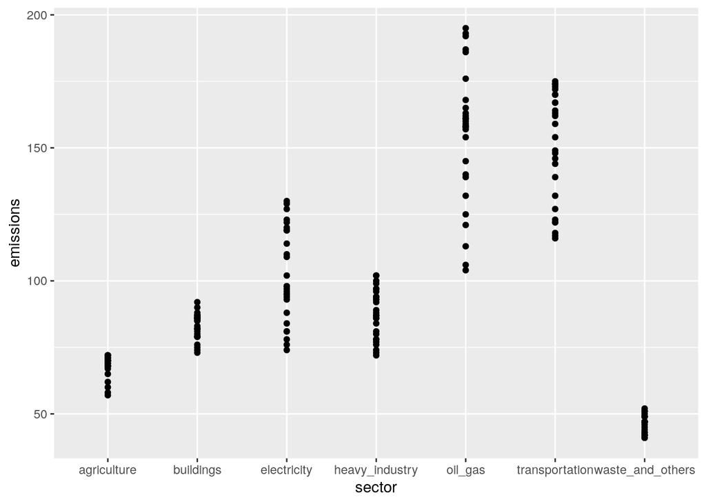

```r
## Always a nice way to start: scatter plot
## Here we’ll do it by sector
ggplot(data = ghg, aes(x = sector, y = emissions)) + geom_point()
```

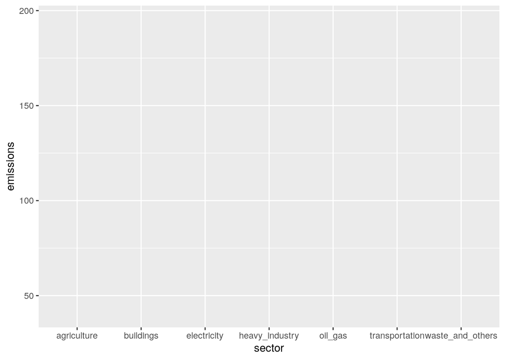

```r
## Try just this: no points!
ggplot(data = ghg, aes(x = sector, y = emissions))
```

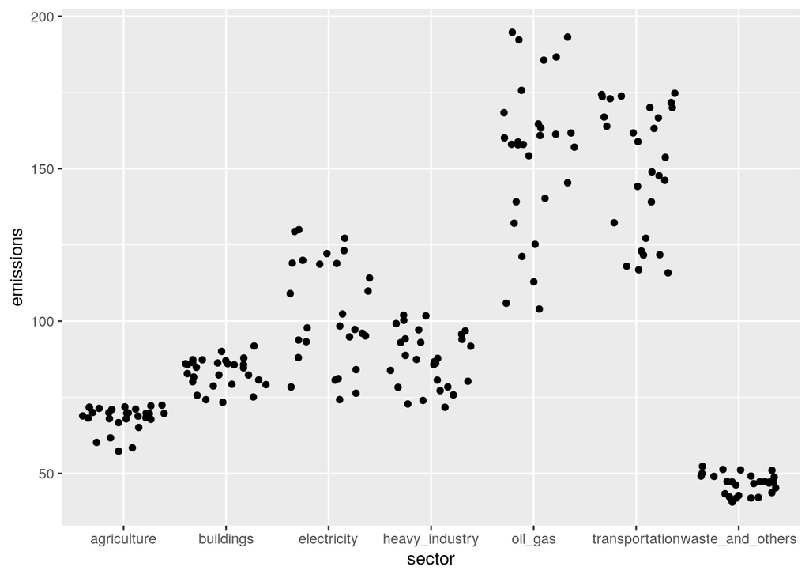

```r
## Jitter it up
ggplot(data = ghg, aes(x = sector, y = emissions)) + geom_jitter()
```

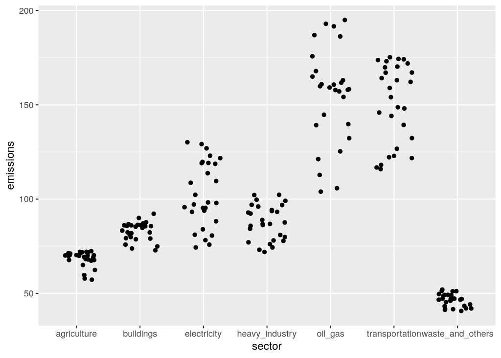

```r
## Tighten the spread
ggplot(data = ghg, aes(x = sector, y = emissions)) + geom_jitter(width = 0.3)
```

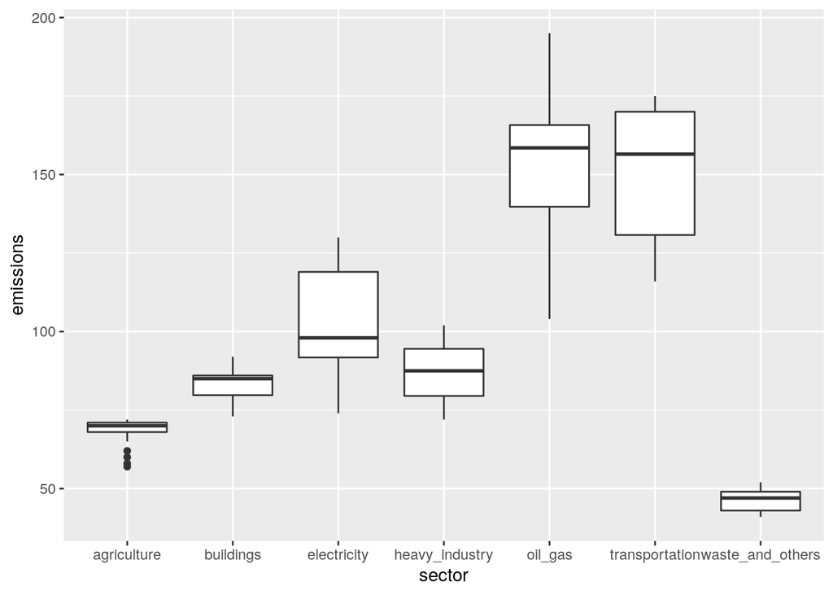

```r
## Box plot (shows first and third quartiles, and median)
## https://ggplot2.tidyverse.org/reference/geom_boxplot.html
ggplot(data = ghg, aes(x = sector, y = emissions)) + geom_boxplot()
```

```r
## Compare the oil_gas column to the summary data here
ghg %>% filter(sector == "oil_gas") %>% summary()
```

```
##       year         sector            emissions
##  Min.   :1990   Length:28          Min.   :104.0
##  1st Qu.:1997   Class :character   1st Qu.:139.8
##  Median :2004   Mode  :character   Median :158.5
##  Mean   :2004                      Mean   :154.9
##  3rd Qu.:2010                      3rd Qu.:165.8
##  Max.   :2017                      Max.   :195.0
```

## Exercise 1

- Add `geom_jitter()` to add the points to the box plot.
- What happens if you reverse the order and put `geom_jitter()` before `geom_boxplot()`?
- What happened is because order matters in ggplot commands.
- After trying this, try using geom_boxplot(alpha = 0.5) instead. The alpha setting controls transparency.

Box plots are useful summaries, but hide the shape of the distribution. For example, if the distribution is bimodal, we would not see it in a box plot. An alternative to the box plot is the violin plot, where the shape (of the density of points) is drawn.

Try `geom_violin()` as well.

Here’s one with some extra new stuff to try if you have time:

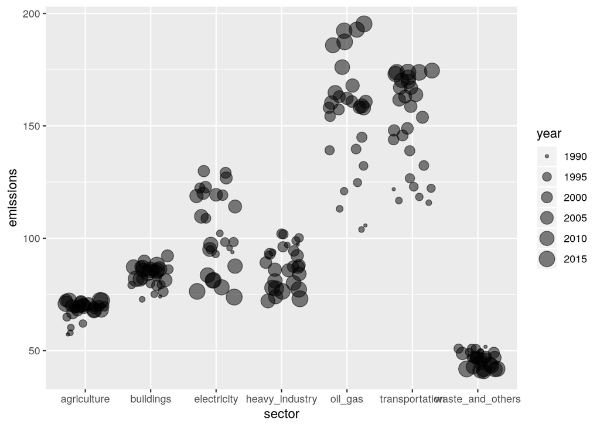

```r
ggplot(data = ghg, aes(x = sector, y = emissions)) + geom_jitter(width = 0.3, aes(size = year), alpha = 0.5)
```

## Points and lines

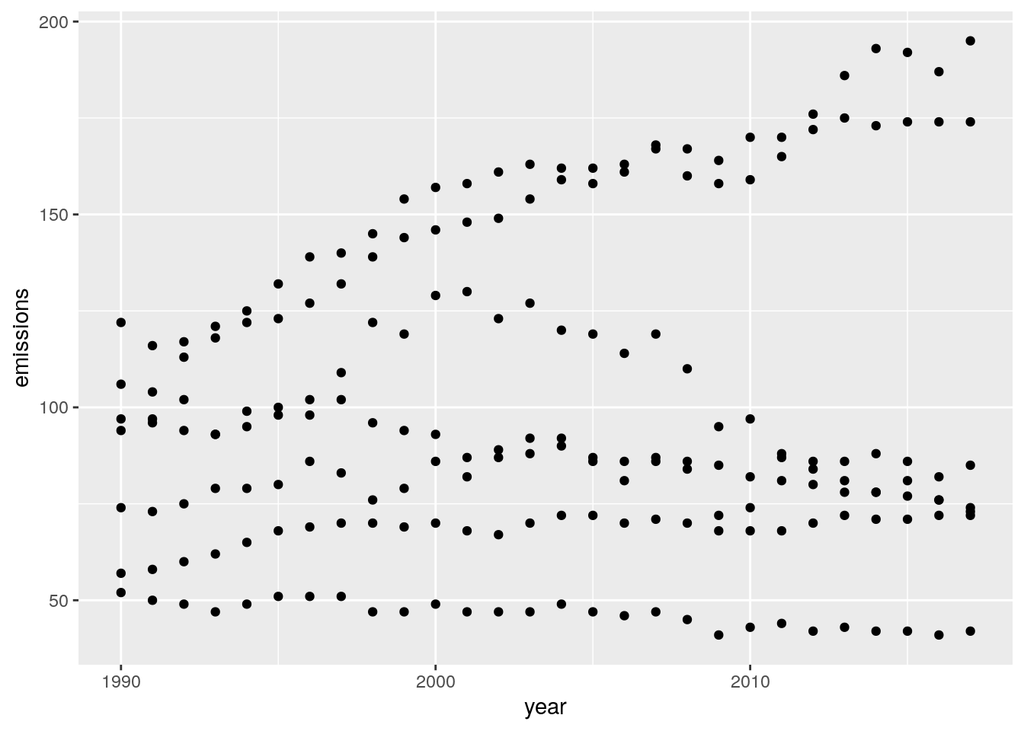

```r
## Now we’ll put year on the x-axis
## And we’ll leave out “data =” because it’s unnecessary

## Scatter plot
ggplot(ghg, aes(x = year, y = emissions)) + geom_point()
```

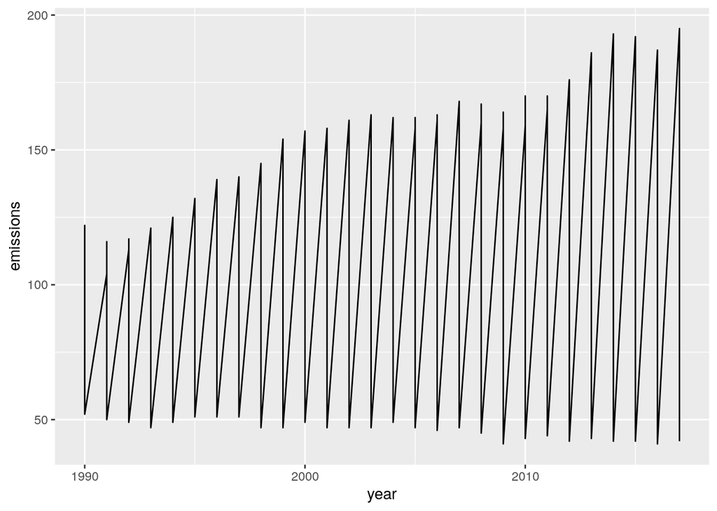

```r
## Just lines
ggplot(ghg, aes(x = year, y = emissions)) + geom_line()
```

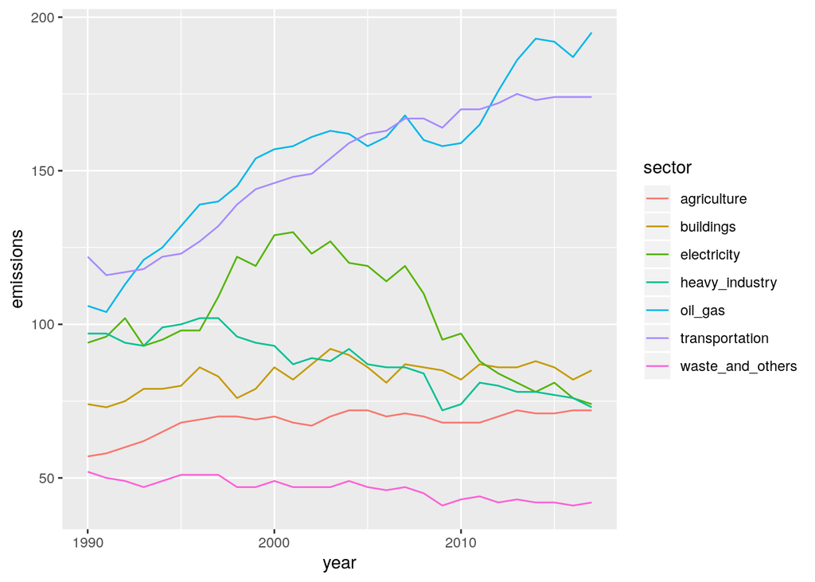

```r
## That didn’t work!
## We need to connect it by sector, and
## specifying colours is enough for R to know what to do
ggplot(ghg, aes(x = year, y = emissions)) + geom_line(aes(colour = sector))
```

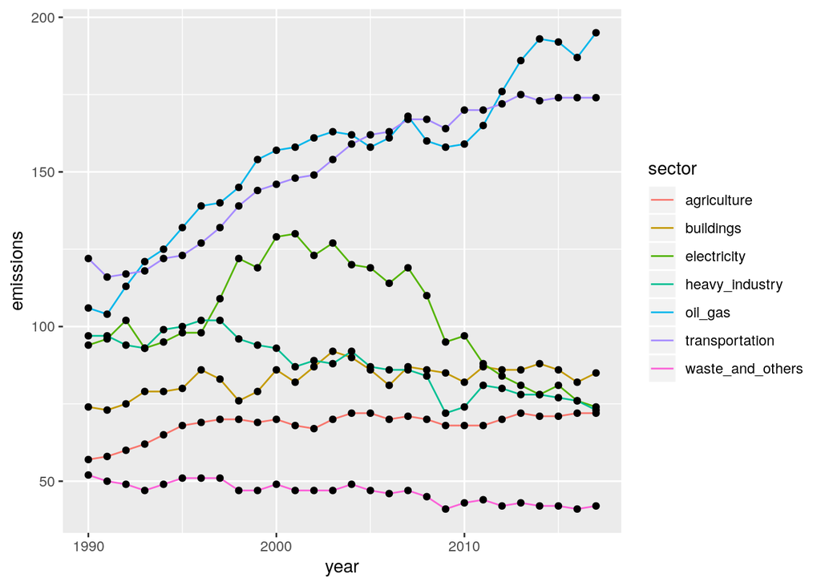

```r
## Lines and points
ggplot(ghg, aes(x = year, y = emissions)) + geom_line(aes(colour = sector)) + geom_point()
```

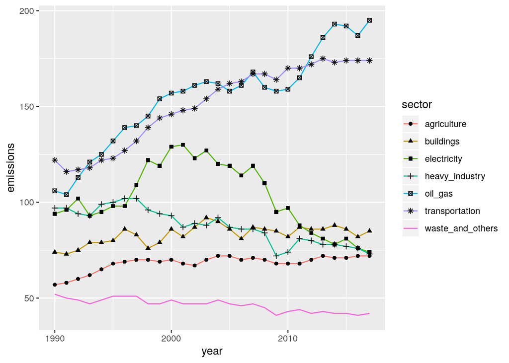

```r
## Lines and shaped points
ggplot(ghg, aes(x = year, y = emissions)) + geom_line(aes(colour = sector)) + geom_point(aes(shape = sector))
```

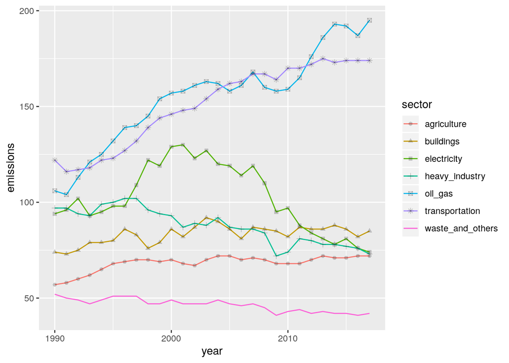

```r
## Lines and softer shaped points
ggplot(ghg, aes(x = year, y = emissions)) + geom_line(aes(colour = sector)) + geom_point(aes(shape = sector), alpha = 0.2)
```

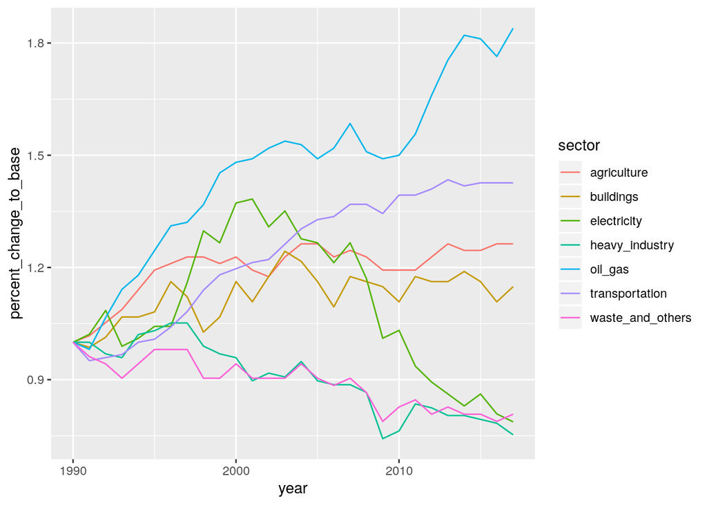

```r
## What does this do?
ghg %>% group_by(sector) %>% mutate(percent_change_to_base = emissions / emissions[1]) %>% ggplot(aes(x = year, y = percent_change_to_base)) + geom_line(aes(colour = sector))
```

## Exercise 2

- Try adding points to this new plot, like before, and also try it with an alpha setting.
- Does this different presentation of the data give you a different understanding of the emissions by sector?

Try picking that last command apart by just looking at the data produced by the `mutate` command. You can even pipe this to `tail()` to see the bottom.

```r
ghg %>% group_by(sector) %>% mutate(percent_change_to_base = emissions / emissions[1])
```

```
## # A tibble: 196 x 4
## # Groups:   sector [7]
##     year sector           emissions percent_change_to_base
##    <dbl> <chr>                <dbl>                  <dbl>
##  1  1990 oil_gas                106                  1
##  2  1990 transportation         122                  1
##  3  1990 buildings               74                  1
##  4  1990 electricity             94                  1
##  5  1990 heavy_industry          97                  1
##  6  1990 agriculture             57                  1
##  7  1990 waste_and_others        52                  1
##  8  1991 oil_gas                104                  0.981
##  9  1991 transportation         116                  0.951
## 10  1991 buildings               73                  0.986
## # … with 186 more rows
```

```r
ghg %>% group_by(sector) %>% mutate(percent_change_to_base = emissions / emissions[1]) %>% tail()
```

```
## # A tibble: 6 x 4
## # Groups:   sector [6]
##    year sector           emissions percent_change_to_base
##   <dbl> <chr>                <dbl>                  <dbl>
## 1  2017 transportation         174                  1.43
## 2  2017 buildings               85                  1.15
## 3  2017 electricity             74                  0.787
## 4  2017 heavy_industry          73                  0.753
## 5  2017 agriculture             72                  1.26
## 6  2017 waste_and_others        42                  0.808
```

```r
## Bar plots
```

```r
ghg %>% group_by(sector) %>% mutate(percent_change_to_base = emissions / emissions[1]) %>% tail()## Emissions are added up automatically
```

```
## # A tibble: 6 x 4
## # Groups:   sector [6]
##    year sector           emissions percent_change_to_base
##   <dbl> <chr>                <dbl>                  <dbl>
## 1  2017 transportation         174                  1.43
## 2  2017 buildings               85                  1.15
## 3  2017 electricity             74                  0.787
## 4  2017 heavy_industry          73                  0.753
## 5  2017 agriculture             72                  1.26
## 6  2017 waste_and_others        42                  0.808
```

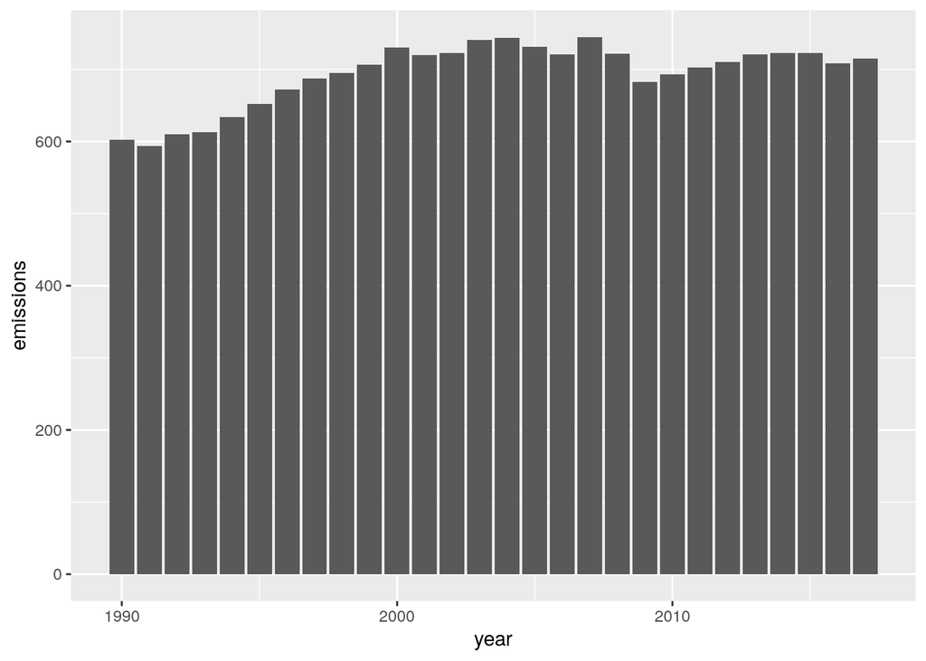

```r
ggplot(ghg, aes(x = year, y = emissions)) + geom_col()
```

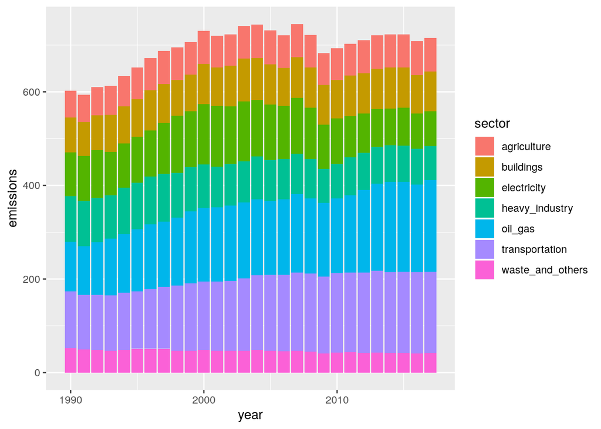

```r
## Fill (with colour) by sector
ggplot(ghg, aes(x = year, y = emissions)) + geom_col(aes(fill = sector))
```

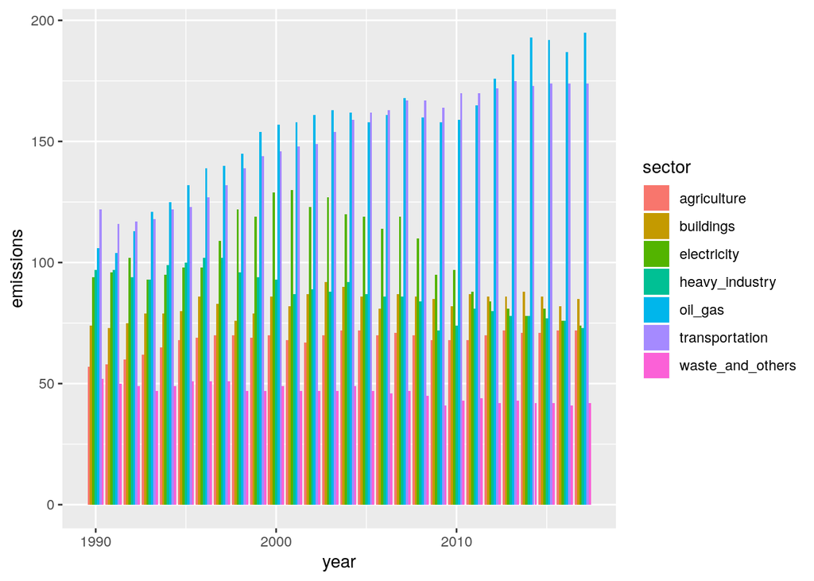

```r
## Break it up by sector, dodge the bars
ggplot(ghg, aes(x = year, y = emissions)) + geom_col(aes(fill = sector), position = "dodge")
```

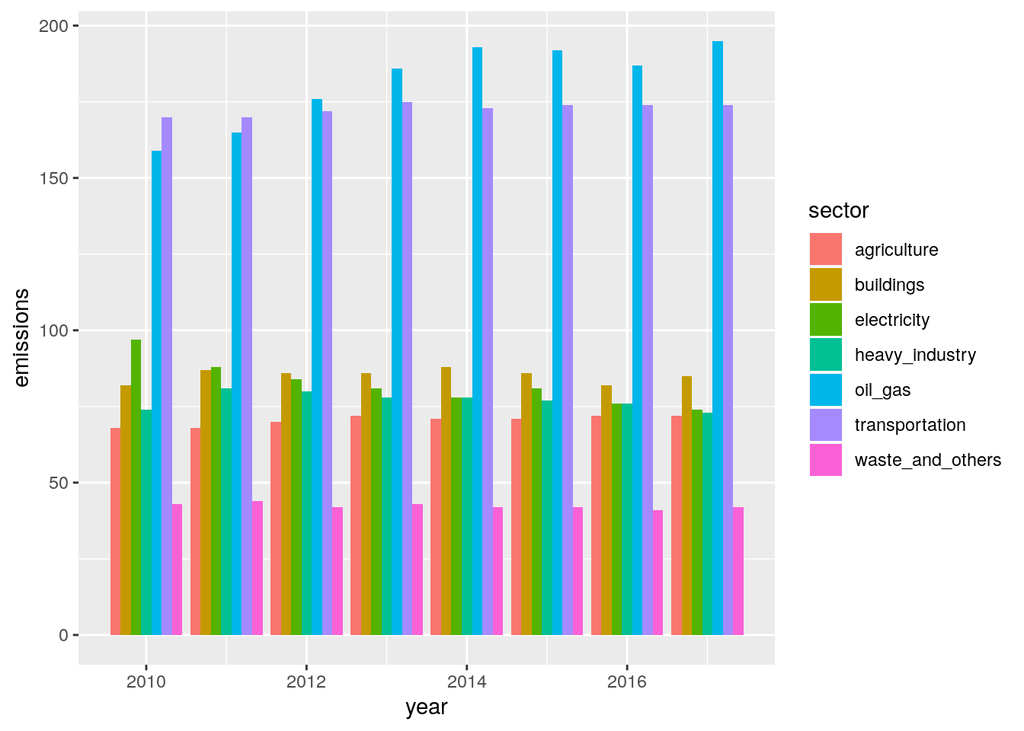

```r
## Smaller portion of that
ggplot(ghg %>% filter(year >= 2010), aes(x = year, y = emissions)) + geom_col(aes(fill = sector), position = "dodge")
```

## Exercise 3

Try `position = "fill"` instead of “dodge”. (This is different from the fill aesthetic.) What does that do?

Try

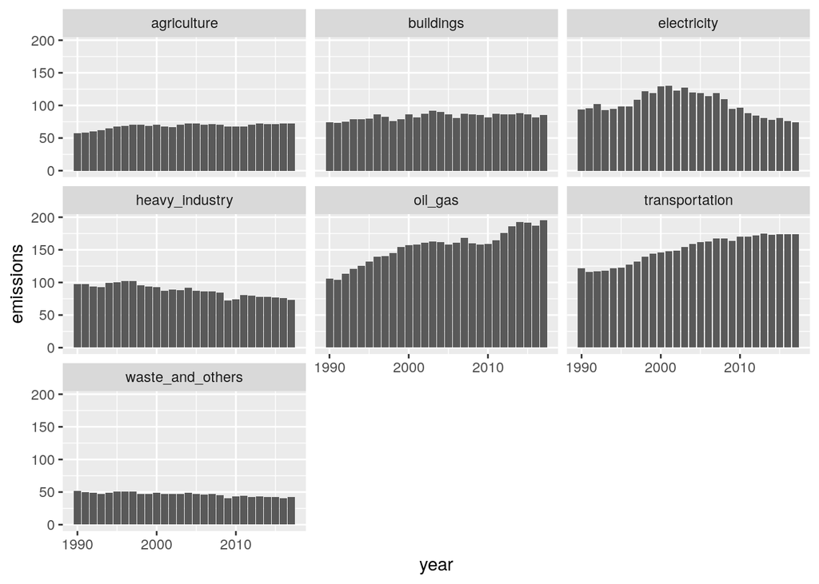

```r
ggplot(ghg, aes(x = year, y = emissions)) + geom_col() + facet_wrap(~ sector)
```

## Customizing the bar plot

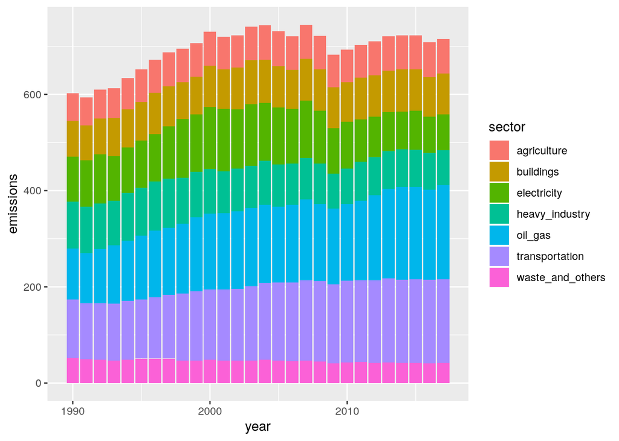

```r
## Back to basic bar plot

ggplot(ghg, aes(x = year, y = emissions)) + geom_col(aes(fill = sector))
```

```r
## But the sectors are in alphabetical order
## (which is a very sensible default)
## We want it so biggest is at the bottom

## Arrange the ordering

## First, see what’s going on
ghg %>% filter(year == 2017)
```

```
## # A tibble: 7 x 3
##    year sector           emissions
##   <dbl> <chr>                <dbl>
## 1  2017 oil_gas                195
## 2  2017 transportation         174
## 3  2017 buildings               85
## 4  2017 electricity             74
## 5  2017 heavy_industry          73
## 6  2017 agriculture             72
## 7  2017 waste_and_others        42
```

```r
ghg %>% filter(year == 2017) %>% arrange(emissions)
```

```
## # A tibble: 7 x 3
##    year sector           emissions
##   <dbl> <chr>                <dbl>
## 1  2017 waste_and_others        42
## 2  2017 agriculture             72
## 3  2017 heavy_industry          73
## 4  2017 electricity             74
## 5  2017 buildings               85
## 6  2017 transportation         174
## 7  2017 oil_gas                195
```

```r
ghg %>% filter(year == 2017) %>% arrange(emissions) %>% pull(sector)
```

```
## [1] "waste_and_others" "agriculture"      "heavy_industry"   "electricity"
## [5] "buildings"        "transportation"   "oil_gas"
```

```r
## Now save it and set it
sector_order <- ghg %>% filter(year == 2017) %>% arrange(emissions) %>% pull(sector)
sector_order
```

```
## [1] "waste_and_others" "agriculture"      "heavy_industry"   "electricity"
## [5] "buildings"        "transportation"   "oil_gas"
```

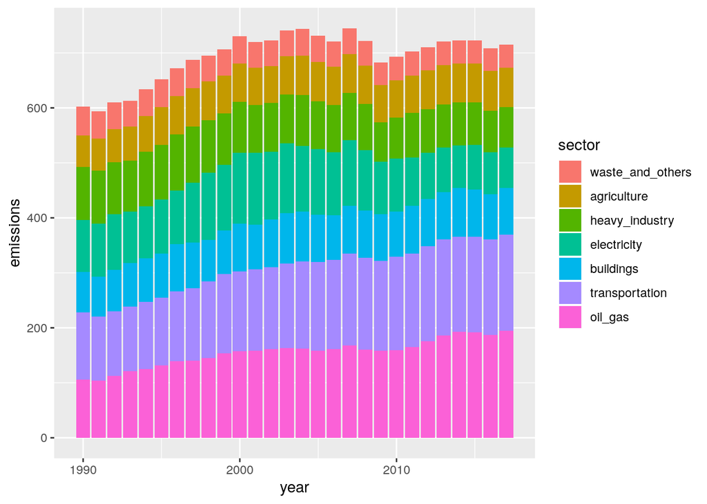

```r
## Make a copy; don’t change the original
ghg_ordered <- ghg
ghg_ordered$sector <- factor(ghg_ordered$sector, levels = sector_order)

## Plot with reordered sectors
## Add in labels while we’re at it
ggplot(ghg_ordered, aes(x = year, y = emissions)) + geom_col(aes(fill = sector))
```

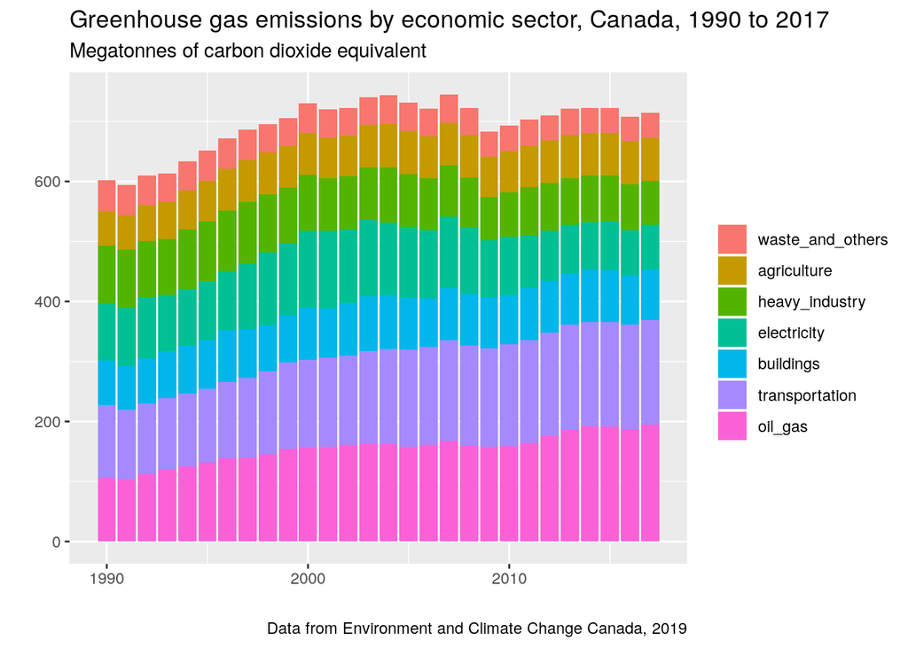

```r
## Add titles and labels
ggplot(ghg_ordered, aes(x = year, y = emissions)) + geom_col(aes(fill = sector)) + labs (title = "Greenhouse gas emissions by economic sector, Canada, 1990 to 2017", subtitle = "Megatonnes of carbon dioxide equivalent", x = "", y = "", caption = "Data from Environment and Climate Change Canada, 2019", fill = "")
```

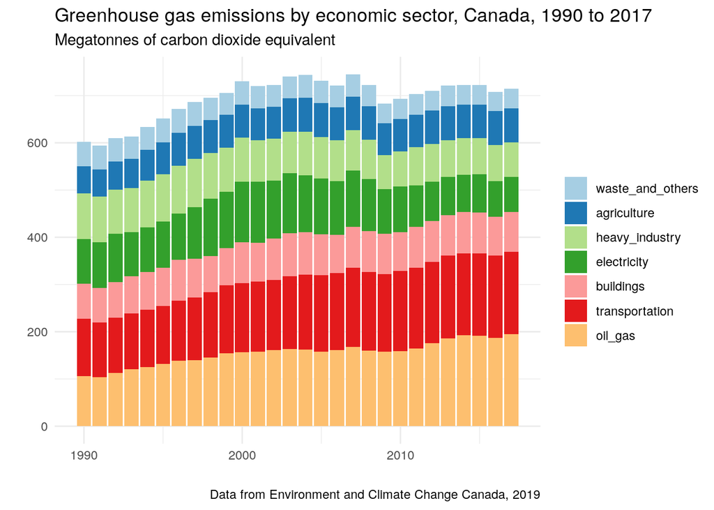

```r
## Change colours and the overall look
ggplot(ghg_ordered, aes(x = year, y = emissions)) + geom_col(aes(fill = sector)) + labs (title = "Greenhouse gas emissions by economic sector, Canada, 1990 to 2017", subtitle = "Megatonnes of carbon dioxide equivalent", x = "", y = "", caption = "Data from Environment and Climate Change Canada, 2019", fill = "") + scale_fill_brewer(palette = "Paired") + theme_minimal()
```

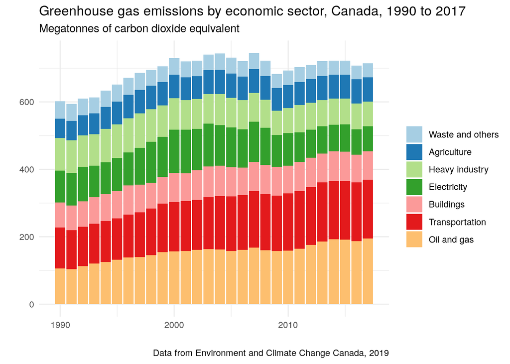

```r
## Fix the names of the sectors
levels(ghg_ordered$sector) <- c("Waste and others", "Agriculture", "Heavy industry", "Electricity", "Buildings", "Transportation", "Oil and gas")

## Now rerun the previous plot
ggplot(ghg_ordered, aes(x = year, y = emissions)) + geom_col(aes(fill = sector)) + labs (title = "Greenhouse gas emissions by economic sector, Canada, 1990 to 2017", subtitle = "Megatonnes of carbon dioxide equivalent", x = "", y = "", caption = "Data from Environment and Climate Change Canada, 2019", fill = "") + scale_fill_brewer(palette = "Paired") + theme_minimal()
```

## Exercise 4

Try customizing the plot further by setting the x- and y-axis labels and editing the titles and the caption.

Try adding `position = "fill"` to `geom_col(aes(fill = sector))` (after the aesthetic, before the final brackets).

Try it with `geom_line(aes(colour = sector))` instead of the `geom_col()`. How does this make the data look different?